# Donnermeyer_Homework_2

Sam Donnermeyer

9/11/2020

## Hand-In Homework #2

### 1 - Problem #54, pg. 156

A tire manufacturer believes that the tread life of its snow tires can be described by a Normal model with a mean of 32,000 miles and a standard deviation of 2,500 miles.

1. If you buy one of these tires, would it be reasonable for you to hope it will last 40,000 miles? Explain.

No, it would be totally unreasonable for you to hope that the tires will last 40,000 miles because only about 0.1% tires will last until 40,000 miles of use.

2. Approximately what fraction of these tires can be expected to last less than 30,000 miles?

According to the Normal model, approximately 21.2% of tires will last less than 30,000 miles.

3. Approximately what fraction of these tires can be expected to last between 30,000 and 35,000 miles?

According to the Normal model, approximately 67.3% of tires would last between 30,000 and 35,000 miles.

4. Estimate the IQR of the tread lives.

The IQR of the tire’s tread life is approximately 3372 miles which is from 33686 - 30314.

5. In planning a marketing strategy, a local tire dealer wants to offer a refund to any customer whose tires fail to last a certain number of miles. However, the dealer does not want to take too big a risk. If the dealer is willing to give refunds to no more than 1 of every 25 customers, for what mileage can he guarantee these tires to last?

If the local tire dealer wants to refund no more than 1 of every 25 customers, the tire mileage must be guaranteed to at a minimum 27623 miles.

### 2 - Hearing Impairment in Dalmatian Dogs

The relationship between eye color and degree of impairment: deaf, unilateral hearing (one ear), bilateral hearing (both ears).

#### Two-Way Table of the counts with marginal totals

```r
# Create two-way table of dalmatian tibble
dal_table = addmargins(xtabs(Count~Hearing+EyeColor,data=dalmatian))
dal_table
```

```
##             EyeColor
## Hearing      Blue Brown  Sum
##   Bilateral   273  3467 3740
##   Deaf        102   324  426
##   Unilateral  179   988 1167
##   Sum         554  4779 5333
```

#### A two-way table showing the conditional distribution of the hearing variable given each eye color.

```r
# Conditional distribution of hearing variable given each eye color
dal_condit = round(prop.table(xtabs(Count~Hearing+EyeColor,data=dalmatian),2),3)
dal_condit
```

```
##             EyeColor
## Hearing       Blue Brown
##   Bilateral  0.493 0.725
##   Deaf       0.184 0.068
##   Unilateral 0.323 0.207
```

#### Segmented bar chart comparing the conditional distributions in the previous table.

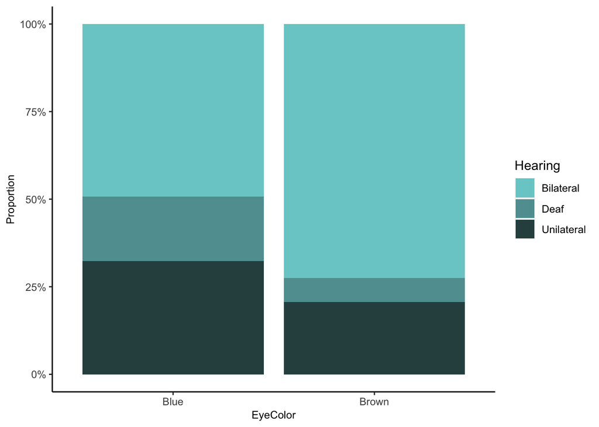

```r
# Segmented bar chart
ggplot(dalmatian,aes(x=EyeColor,y=Count,fill=Hearing)) +
  geom_col(position="fill") +
  # Change the Y-axis to percentage
  scale_y_continuous(labels = percent_format(accuracy = 1)) +
  ylab("Proportion") +
  # Change Fill colors
  scale_fill_manual(values = c("darkslategray3", "cadetblue", "darkslategrey")) +
  # Theme
  theme(
    # hide panel borders and remove grid lines
    panel.background = element_rect(fill = "white"),
    panel.border = element_blank(),
    panel.grid.major = element_blank(),
    panel.grid.minor = element_blank(),
    # change axis titles
    axis.line = element_line(color = "black"),
    axis.title = element_text(size=9),
    # Change the title orientation
    plot.title = element_text(hjust = 0.5)
  )
```